# National Esthetics Written Practical Examination CIB

National-Interstate Council of State Boards of Cosmetology (NIC)

Effective Date: September 01, 2025 Revision Date: March 01, 2026

[figure not shown]

## CANDIDATE INFORMATION BULLETIN (CIB)

**EXAMINATION CONTENT AND IMPORTANT INSTRUCTIONS**

*Please visit your official examination provider website OR www.nictesting.org for the most current bulletin prior to testing.*

The National Esthetics Written Practical Examination is a licensure examination for Esthetics, developed by the National-Interstate Council of State Boards of Cosmetology (NIC).

This bulletin contains IMPORTANT INFORMATION regarding National Esthetics Written Practical Examination content and administration for core services and additional sections and references.

The time allowed for this examination is 90 minutes.

*PLEASE REVIEW ALL INFORMATION CAREFULLY.*

For each NIC National Written Practical Examination, there are multiple parts to every Candidate Information Bulletin (CIB):

- **Important Instructions and Examination Content Domain Sections** – This provides information and guidelines related to administration of the Written Practical examination and information about the scope of content covered in the Written Practical examination.
- **References** – This provides a list of references used to develop and support the content covered in NIC examinations. References will be the same for Theory, Practical, Written Practical, and Additional Sections for each exam.

*BE CERTAIN TO REVIEW ALL PARTS OF THIS NIC EXAMINATION CIB CAREFULLY!*

## IMPORTANT INSTRUCTIONS

### General

- Do not leave the examination area without permission. Permission must be obtained to leave the examination area for any reason, including restroom usage or at the completion of the examination. *Picture ID is required for re-entry into the examination.*
- All examinations are administered in a testing environment.

### Standardized Administration

Due to standardization of the NIC National Examinations, proctors and examiners are required to adhere to the following standards:

- With the exception of verbal instructions, proctors and examination administration personnel are NOT allowed to speak with candidates.
- If a candidate experiences an emergency situation, they may notify the proctor by raising their hand.

#### Prohibited Items

- The following provides examples of materials and actions that are prohibited in the examination room during the examination administration:
  - Possession of cellular phones, watches (of any kind), pagers, tablets, computers, projectors, cameras, or any other electronic or recording devices, printed materials, or handwritten notes.
  - Purses, bags, coats, hats, and any other personal items not directly needed to complete the examination, are not allowed.
- Communicating to other candidates or any examiner.
- Exhibiting disruptive behavior. The above referenced items or actions are not an exhaustive list.

Failure to comply with any of these conditions or exhibiting ANY behavior that suggests an effort to cheat will result in immediate dismissal from the examination and the candidates’ actions reported to the proper authorities.

## ESTHETICS WRITTEN PRACTICAL EXAMINATION CONTENT OUTLINE

### Domain Details

The following outlines the scope of content covered by the NIC National Esthetics Written Practical Examination. The percentages represent the percentage of items from each domain. The examination contains 50 items, of which 40 items are weighted and contribute to the candidate’s final score. The Core Domain Sections are based on the national job analysis.

1. WORK AREA PREPARATION AND SET UP OF SUPPLIES (10%)
   1. Elements include:
      1. Disinfects all work areas completely with product that is EPA-registered disinfectant that is virucidal, bactericidal, and fungicidal
      2. Sanitizes hands
      3. Universal products are labeled in English
      4. Items to be disinfected, soiled linens, and trash are disposed of in correct containers throughout section
2. CLIENT PREPARATION AND BASIC FACIAL (23%)
   1. Elements include:
      1. Basic facial products are labeled in English
      2. Implements and supplies are visibly clean
      3. Cleanses entire face
      4. Performs exfoliation with manual exfoliant using an implement or material on entire face excluding eyes and lips
      5. Steams the face with towel and removes residual product completely
      6. Demonstrates facial massage procedure using 4 different types of facial massage movements
      7. Demonstrates facial mask application and concludes the service
      8. Maintains drape throughout section
      9. Items to be disinfected, soiled linens, and trash are disposed of in correct containers throughout section
3. WORK AREA AND NEW CLIENT PREPARATION, AND SET UP OF SUPPLIES (10%)
   1. Elements include:
      1. Disinfects all work areas completely with product that is EPA-registered disinfectant that is virucidal, bactericidal, and fungicidal
      2. Sanitizes hands
      3. Universal products are labeled in English
      4. Items to be disinfected, soiled linens, and trash are disposed of in correct containers throughout section
4. HAIR REMOVAL OF THE EYEBROW USING SIMULATED SOFT WAX AND TWEEZING (15%)
   1. Elements include:
      1. Hair removal of the eyebrow products are labeled in English
      2. Implements and supplies are visibly clean
      3. Demonstrates application of simulated soft wax procedure along entire length of one eyebrow
      4. Demonstrates removal of simulated soft wax
      5. Demonstrates tweezing procedure
      6. Maintains drape throughout section
      7. Items to be disinfected, soiled linens, and trash are disposed of in correct containers throughout section
5. FACIAL MAKEUP (22%)
   1. Elements include:
      1. Facial makeup products are labeled in English
      2. Implements and supplies are visibly clean
      3. Applies foundation to cover face
      4. Applies blush
      5. Applies eyeliner
      6. Applies mascara
      7. Applies lip color
      8. Maintains drape throughout section
      9. Items to be disinfected, soiled linens, and trash are disposed of in correct containers throughout section
6. BLOOD EXPOSURE PROCEDURE (20%)
   1. Elements include:
      1. Blood exposure supplies and materials are labeled in English
      2. Removes materials from the first aid kit
      3. Supplies and materials are visibly clean
      4. Candidate wears gloves
      5. Cleans injured area with antiseptic
      6. Covers with dressing that is absorbent and secured
      7. Disposes of all contaminated supplies

## NATIONAL ESTHETICS WRITTEN PRACTICAL EXAMINATION SAMPLE QUESTIONS

1. During extractions, the implement falls to the floor. What should the practitioner do next?

   A. Pick up the implement, wash it, and continue with extractions

   B. Pick up the implement, place it in the “items to be disinfected” container, replace gloves, and continue with extractions

   C. Pick up the implement, place it on the workstation, wash hands, and continue with extractions

   D. Stop the service, disinfect the entire work area, replace gloves, and continue with extractions

2. An adolescent entering puberty has inquired about getting rid of blackheads and milia. The MOST effective way to clear up skin is

   A. the sale of multiple skin care products.

   B. daily treatments within the salon.

   C. the removal and cleansing of blemishes.

   D. chemicals and laser treatments.

3. When analyzing the skin through a Wood’s lamp, hyperpigmentation will appear

   A. blue.

   B. yellow.

   C. orange.

   D. brown

4. During the consultation, a client indicates they have vitiligo. How does this appear on the skin?

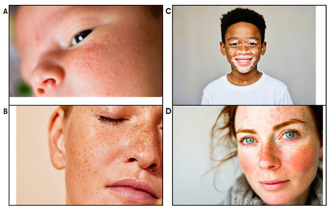

5. Select all images that show improper or no bracing during a makeup application.

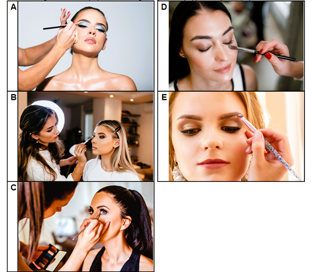

**Answer Key**

| Item | Key |
| --- | --- |
| 1 | B |
| 2 | C |
| 3 | D |
| 4 | C |
| 5 | B, D |

## NATIONAL-INTERSTATE COUNCIL OF STATE BOARDS OF COSMETOLOGY (NIC) REFERENCES

This list provides the references used to develop and support the content covered in the NIC National Esthetics examinations. References will be the same across exam types for each exam. Candidates are responsible for using these most updated versions of references, as these editions were used to reference test material.

Reference Date: March 01, 2026

### Standard

*Milady Standard Esthetics Fundamentals and Foundations (2-book set)*

Copyrighted Foundations 2020,

12th Edition

ISBN: 9780357263792

Milady www.Milady.com

Contact: Info@Milady.com;

*Pivot Point Fundamentals: Esthetics, (101E – 111E)*

Copyrighted ©2022 Pivot Point International, Inc.

1st Edition, 3rd Printing, September 2022

ISBN 978-1-951862-26-8

Pivot Point International, Inc. https://www.pivot-point.com/shop/

Contact: info@pivot-point.com; 847-886-0500

### Supplemental

*Milady Standard Advanced Esthetics*

Copyrighted 2026

3rd Edition

9780357873069

Milady www.Milady.com

Info@Milady.com;

*Milady Standard Advanced Esthetics*

Copyrighted 2013

2013, 2nd Edition

ISBN: 9781111139094

Milady www.Milady.com

Contact: Info@Milady.com;

*The Epidermal Cell Therapy Skillsbook*

Copyrighted 2015

Author: L. Saphonia Gee, L.M.E., CIDESCO Diplomat L. Saphonia Gee

Copyright 2025 National-Interstate Council of State Boards of Cosmetology, Inc.